# Computational Linear Algebra: Exam 3

Vichearith Meas

## *Tuesday, May 3 - Monday, May 9, 2022*

### Upload an html file to Moodle and turn in any hand written work by noon on Monday, May 9, 2022

### I pledge my honor that I have not participated in any dishonest work on this exam, nor do I know of dishonest work done by other students on this exam.

The following line sources functions from the class file `365Functions.r`. Feel free to use any of these functions.

```r
source("https://www.macalester.edu/~dshuman1/365/365Functions.r")
source("https://www.macalester.edu/~dshuman1/365/2022.365.E3.Data.r")
library(Matrix)
library(expm)
library(tidyr)
library(ggplot2)
# library(splines)
library(tidyverse)
library(ggrepel)
library(pracma)
```

## Problem 1

### a

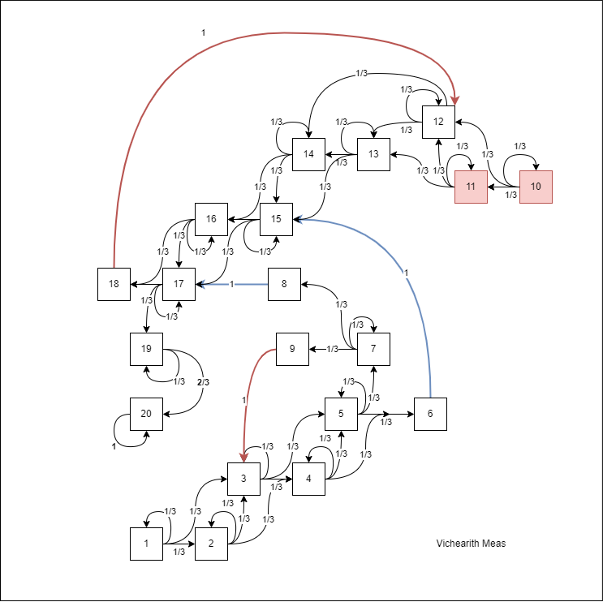

State Diagram

```r
options(width=1000, digits = 2)
p1.A = spMatrix(ncol = 20, nrow=20,
                i = c(1:20, 1:19, 1:18) ,
                j = c(1:20, 2:20, 3:20),
                x = c(rep(1/3, 20),rep(1/3, 19),rep(1/3, 18)))
# If the player reach state 20, the player stays the in the same state
p1.A[20,20] = 1
#  A space that is the top of a chute, she instantaneously falls to the bottom of the slide
p1.A[9,] = 0
p1.A[9,3] = 1
p1.A[18,] = 0
p1.A[18,12] = 1
#  player reaches the bottom of the ladder, the player is instantaneously transferred to the top of the ladder
p1.A[6,] = 0
p1.A[6,15] = 1
p1.A[8,] = 0
p1.A[8,17] = 1
# 2 changes to reach 20 from 19
p1.A[19,20] = 2/3


#  Check row sum
rowSums(p1.A)
```

```
##  [1] 1 1 1 1 1 1 1 1 1 1 1 1 1 1 1 1 1 1 1 1
```

```r
p1.A
```

```
## 20 x 20 sparse Matrix of class "dgTMatrix"
##
##  [1,] 0.33 0.33 0.33 .    .    .    .    .    .    .    .    .    .    .    .    .    .    .    .    .
##  [2,] .    0.33 0.33 0.33 .    .    .    .    .    .    .    .    .    .    .    .    .    .    .    .
##  [3,] .    .    0.33 0.33 0.33 .    .    .    .    .    .    .    .    .    .    .    .    .    .    .
##  [4,] .    .    .    0.33 0.33 0.33 .    .    .    .    .    .    .    .    .    .    .    .    .    .
##  [5,] .    .    .    .    0.33 0.33 0.33 .    .    .    .    .    .    .    .    .    .    .    .    .
##  [6,] .    .    .    .    .    .    .    .    .    .    .    .    .    .    1.00 .    .    .    .    .
##  [7,] .    .    .    .    .    .    0.33 0.33 0.33 .    .    .    .    .    .    .    .    .    .    .
##  [8,] .    .    .    .    .    .    .    .    .    .    .    .    .    .    .    .    1.00 .    .    .
##  [9,] .    .    1.00 .    .    .    .    .    .    .    .    .    .    .    .    .    .    .    .    .
## [10,] .    .    .    .    .    .    .    .    .    0.33 0.33 0.33 .    .    .    .    .    .    .    .
## [11,] .    .    .    .    .    .    .    .    .    .    0.33 0.33 0.33 .    .    .    .    .    .    .
## [12,] .    .    .    .    .    .    .    .    .    .    .    0.33 0.33 0.33 .    .    .    .    .    .
## [13,] .    .    .    .    .    .    .    .    .    .    .    .    0.33 0.33 0.33 .    .    .    .    .
## [14,] .    .    .    .    .    .    .    .    .    .    .    .    .    0.33 0.33 0.33 .    .    .    .
## [15,] .    .    .    .    .    .    .    .    .    .    .    .    .    .    0.33 0.33 0.33 .    .    .
## [16,] .    .    .    .    .    .    .    .    .    .    .    .    .    .    .    0.33 0.33 0.33 .    .
## [17,] .    .    .    .    .    .    .    .    .    .    .    .    .    .    .    .    0.33 0.33 0.33 .
## [18,] .    .    .    .    .    .    .    .    .    .    .    1.00 .    .    .    .    .    .    .    .
## [19,] .    .    .    .    .    .    .    .    .    .    .    .    .    .    .    .    .    .    0.33 0.67
## [20,] .    .    .    .    .    .    .    .    .    .    .    .    .    .    .    .    .    .    .    1.00
```

### b

```r
# start from the first position
x0<-c(1, rep(0,19))
#  find transpose of matrix
p1.At<-as.matrix(t(p1.A))
p.after.20.turn<-p1.At%^%(20)%*%x0
#  probability to reach 20
p.after.20.turn[20]
```

```
## [1] 0.51
```

### c

The probability that you, David, find me on:

- square 19 is 20.7%
- square 10 is 00.0%

I most likely be on square 17th.

```r
options(digits = 3)
#  update the matrix
p1.A.endless = as.matrix(p1.A)
p1.A.endless[20,] = 0
p1.A.endless[20,1] = 1

p1.At.endless = t(p1.A.endless)
e.out<-eigen(p1.At.endless)
p1.At.endless.longrun = as.numeric(e.out$vectors[,1])

# square 19
p1.At.endless.longrun[19]
```

```
## [1] 0.207
```

```r
# square 10
p1.At.endless.longrun[10]
```

```
## [1] 0
```

```r
# Which state mostly to end up in
match(max(p1.At.endless.longrun), p1.At.endless.longrun)
```

```
## [1] 17
```

### d

As the number of $k$ increase, $A^{(k)}x_0$ converges to the dominant eigenvector of the augmented adjacency matrix, and is therefore a good measure of probability of state I may end up in long term. Therefore, I only need to look at the probability for the state that is asked.

## Problem 2

### a

```r
A<-cbind(c(1,5,-2,3),c(2,-4,2,2),c(1,2,-1,3))

A.out  = svd(A, nu = nrow(A))
(f = A.out$v[,1])
```

```
## [1] -0.798  0.436 -0.417
```

```r
(g = A.out$v[,2])
```

```
## [1] 0.234 0.861 0.452
```

```r
t(A %*% f ) %*% (A %*% g)
```

```
##          [,1]
## [1,] 7.11e-15
```

```r
t(f) %*% g
```

```
##          [,1]
## [1,] 2.22e-16
```

### b

```r
A.out  = svd(A, nu = nrow(A))

h = 2*A.out$u[,4]

vnorm(as.matrix(h), p = 2)
```

```
## [1] 2
```

```r
t(A) %*% h
```

```
##          [,1]
## [1,] 2.22e-16
## [2,] 1.33e-15
## [3,] 8.88e-16
```

### c

$AA^T$ is real and symmetric so it is diagonalizable. $AA^T$ has the of 3 and therefore not a full rank and $A$ is not full rank.

```r
AA = A %*% t(A)

svd(AA)
```

```
## $d
## [1] 5.92e+01 2.26e+01 1.79e-01 1.82e-15
##
## $u
##         [,1]   [,2]   [,3]   [,4]
## [1,] -0.0446  0.506 -0.689 -0.516
## [2,] -0.8531 -0.288 -0.350  0.258
## [3,]  0.3747  0.169 -0.481  0.775
## [4,] -0.3603  0.795  0.414  0.258
##
## $v
##         [,1]   [,2]   [,3]   [,4]
## [1,] -0.0446  0.506 -0.689  0.516
## [2,] -0.8531 -0.288 -0.350 -0.258
## [3,]  0.3747  0.169 -0.481 -0.775
## [4,] -0.3603  0.795  0.414 -0.258
```

```r
Rank(AA)
```

```
## [1] 3
```

### d

**TRUE** Because there exists eigenvalues of 1 meaning that there is eignevector(s) $y$ whose direction and length is preserved when multiply by $S$.

```r
out <- svd(A)
U <- out$u
p2.S <- U%*%t(U)

(p2.S.eignen = eigen(p2.S))
```

```
## eigen() decomposition
## $values
## [1]  1.00e+00  1.00e+00  1.00e+00 -4.44e-16
##
## $vectors
##        [,1]    [,2]   [,3]   [,4]
## [1,]  0.829  0.0000  0.214  0.516
## [2,] -0.029 -0.6262  0.735 -0.258
## [3,]  0.558 -0.0506 -0.293 -0.775
## [4,]  0.013  0.7780  0.573 -0.258
```

```r
p2.S %*% p2.S.eignen$vectors[,1]
```

```
##        [,1]
## [1,]  0.829
## [2,] -0.029
## [3,]  0.558
## [4,]  0.013
```

### e

$P$ will no nothing to $y$. We know that $Py = (2S - I)y = 2Sy - Iy = 2y - y = y$.

```r
P = 2 * p2.S - diag(1, nrow = 4)
P %*%  p2.S.eignen$vectors[,1]
```

```
##        [,1]
## [1,]  0.829
## [2,] -0.029
## [3,]  0.558
## [4,]  0.013
```

## Problem 3

### a

We know that the first three Legendre polynomials are:
$$\begin{align*}
p_0 &= 1 \\
p_1 &= x ;\\
p_2 &= \frac{1}{2}(3x^2 - 1) \\
p_3 &= \frac{1}{2}(5x^3 - 3x)
\end{align*}$$

$$\| h - f\| = \sqrt{\int_{-1}^{1}|h(x) - f(x)|^2dx}$$
. The norm of $\|h-f\|$ is minimal if $f$ is the orthogonal projection of the function $h$ on the subspace $\mathcal{P}_2$, the space of all degree 2 polynomials.

$\mathcal{P}_2$ consists of orthonormal basis $p_0, p_1, p_2$.

For $p(x) \in \mathcal{P}_2$,
$$p(x) = \frac{\langle h, p_0 \rangle}{\langle p_0, p_0 \rangle} p_0(x) + \frac{\langle h, p_1 \rangle}{\langle p_1, p_1 \rangle} p_1(x) + \frac{\langle h, p_2 \rangle}{\langle p_2, p_2 \rangle} p_2(x)$$

```r
## Checking against 2-norm optimization
h<-function(x){
  2*x^3 + 3*x^2 - 2*x + 3
}

q0<-function(x){sqrt(1/2)}
q1<-function(x){sqrt(1.5)*x}
q2<-function(x){(3*x^2-1)*sqrt(5/8)}
q3<-function(x){(5*x^3-3*x)*sqrt(7/8)}

integrand0 <- function(x) {q0(x)*h(x)}
c0<-integrate(integrand0,lower = -1, upper = 1)
c0<-c0$value

integrand1 <- function(x) {q1(x)*h(x)}
c1<-integrate(integrand1,lower = -1, upper = 1)
c1<-c1$value

integrand2 <- function(x) {q2(x)*h(x)}
c2<-integrate(integrand2,lower = -1, upper = 1)
c2<-c2$value

integrand3 <- function(x) {q3(x)*h(x)}
c3<-integrate(integrand3,lower = -1, upper = 1)
c3<-c3$value

(coeffs<-c(c0,c1,c2))
```

```
## [1]  5.657 -0.653  1.265
```

```r
(mat<-cbind(c(1/sqrt(2),0,0,0),
            c(0,sqrt(1.5),0,0),
            c(-sqrt(5/8),0,3*sqrt(5/8),0)))
```

```
##       [,1] [,2]   [,3]
## [1,] 0.707 0.00 -0.791
## [2,] 0.000 1.22  0.000
## [3,] 0.000 0.00  2.372
## [4,] 0.000 0.00  0.000
```

```r
#  2-norm ||h - f||^2
(poly.coeffs<-mat%*%coeffs)
```

```
##      [,1]
## [1,]  3.0
## [2,] -0.8
## [3,]  3.0
## [4,]  0.0
```

```r
h<-function(x){
  2*x^3 + 3*x^2 - 2*x + 3
}
h.hat = function(x){
  6*x^2 - (4/5)*x + 2
}

h.hat.2 = function(x){
  3*x^2 -0.8*x + 3
}

x<-seq(-1,1,length=1000)
plot(x,h(x),type='l',lwd=3) +
lines(x,h.hat(x),lwd=3,col="red")   # |h - f|
```

```
## integer(0)
```

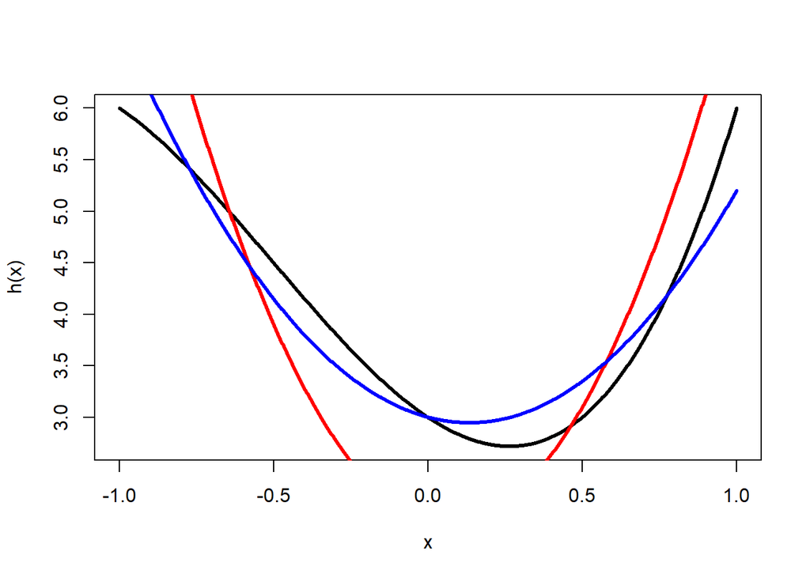

```r
lines(x,h.hat.2(x),lwd=3,col="blue")# |h - f|^2
```

## b

For $g(x) = ax^3 + bx^2 + cx + d$, we can find:

$$p(x) = \frac{\langle g, p_0 \rangle}{\langle p_0, p_0 \rangle} p_0(x) + \frac{\langle g, p_1 \rangle}{\langle p_1, p_1 \rangle} p_1(x) + \frac{\langle g, p_2 \rangle}{\langle p_2, p_2 \rangle} p_2(x)$$

$$\begin{align*}
\langle g, p_0 \rangle &= \int_{-1}^{1}(ax^3 + bx^2 + cx + d)dx &= &2d+\frac{2b}{3} \\
\langle g, p_1 \rangle &= \int_{-1}^{1}(ax^3 + bx^2 + cx + d)(x)dx &= &\frac{2a}{5}+\frac{2c}{3}\\
\langle g, p_2 \rangle &= \int_{-1}^{1}\frac{1}{2}(ax^3 + bx^2 + cx + d)(3x^2 - 1)dx &= &\frac{1}{2}\int _{-1}^1\:\left(3ax^5-ax^3+3x^4b-x^2b+3x^3c-cx+3x^2d-d\right)dx \\
& &= &\frac{1}{2} \Big [\frac{3}{6} ax^6- \frac{1}{4}ax^4+\frac{3}{5}x^5b-\frac{1}{3}x^3b+\frac{3}{4}x^4c-\frac{1}{2}x^2c+\frac{3}{3}x^3d-dx\Big]_{-1}^1\\
& &= &\frac{1}{2} \Big [\frac{1}{2} ax^6- \frac{1}{4}ax^4+\frac{3}{5}x^5b-\frac{1}{3}x^3b+\frac{3}{4}x^4c-\frac{1}{2}x^2c+x^3d-dx\Big]_{-1}^1 \\
& &= &\frac{3}{5}b - \frac{1}{3}b \\
\end{align*}$$

$$\begin{align*}
p(x) &= \frac{2d+\frac{2b}{3}}{2} (1) + \frac{\frac{2a}{5}+\frac{2c}{3}}{\frac{2}{3}}(x) + \frac{\frac{3}{5}b - \frac{1}{3}b}{ \frac{2}{5}} \frac{1}{2}(3x^2 - 1) &= &3x^2 + 6x − 5\\
&= d+x^2b+\frac{\left(3a+5c\right)x}{5} &= & 3x^2 + 6x − 5\\
\end{align*}\\
\begin{cases}
d = -5 \\
b = 3 \\
a = t \quad ; \quad t \in R\\
c = \frac{30-3t}{5}
\end{cases}$$
$$g(x) = tx^3 + 3x^2 + \frac{30-3t}{5}x - 5 \qquad ; \qquad t \in R$$

## Problem 4

Here is the diagram frequency matrix of Lincoln’s Gettysburg address:

```r
print(G)
```

```
##       [,1] [,2] [,3] [,4] [,5] [,6] [,7] [,8] [,9] [,10] [,11] [,12] [,13] [,14] [,15] [,16] [,17] [,18] [,19] [,20] [,21] [,22] [,23] [,24] [,25] [,26]
##  [1,]    0    1    2    5    0    1    4    0    2     0     1     9     0    15     0     1     0    10     5    36     1     8     0     0     1     0
##  [2,]    1    0    0    0    5    0    0    0    1     0     0     1     0     0     1     0     0     2     0     0     2     0     0     0     1     0
##  [3,]   12    0    0    0    4    0    0    2    1     0     0     0     0     0     7     0     0     4     0     1     0     0     0     0     0     0
##  [4,]    2    0    1    6   14    0    0    3   13     0     0     0     0     0     4     1     0     0     4     4     1     1     4     0     0     0
##  [5,]   16    3    8   26    3    5    2    7    6     0     0     4     5    10     5     4     1    22     9    12     2     4     8     0     3     0
##  [6,]    3    0    0    1    0    1    0    0    5     0     0     0     0     0    10     0     0     3     0     3     1     0     0     0     0     0
##  [7,]    5    1    0    0    5    0    1    4    0     0     0     1     0     0     3     1     0     6     0     0     0     0     1     0     0     0
##  [8,]   24    0    0    0   32    1    0    0    7     0     0     1     0     0     8     0     0     0     0     5     1     0     0     0     0     0
##  [9,]    0    1    8    1    3    0    2    0    0     0     0     2     0    16     9     0     0     2     9     8     0     7     0     0     0     0
## [10,]    0    0    0    0    0    0    0    0    0     0     0     0     0     0     0     0     0     0     0     0     0     0     0     0     0     0
## [11,]    0    0    0    0    1    0    0    0    0     0     0     0     0     0     0     0     0     1     0     0     0     0     1     0     0     0
## [12,]    3    0    0    4    6    0    0    1    6     0     0     8     2     3     3     0     0     1     0     1     0     1     1     0     2     0
## [13,]    2    1    0    0    7    0    0    0    1     0     0     0     0     0     0     0     0     0     0     2     0     0     0     0     0     0
## [14,]   10    0    5    9    4    1    9    0    2     0     0     3     2     4    12     0     0     0     4     8     1     1     0     0     2     0
## [15,]    1    3    1    3    0    6    1    1    0     0     0     1     4    20     2     5     0    17     3    13     7     2     3     0     0     0
## [16,]    0    0    0    0    5    0    0    0    0     0     0     4     0     0     4     0     0     2     0     0     0     0     0     0     0     0
## [17,]    0    0    0    0    0    0    0    0    0     0     0     0     0     0     0     0     0     0     0     0     1     0     0     0     0     0
## [18,]    8    0    0    1   26    4    3    0    1     0     1     3     0     1     6     2     0     0     5    12     3     0     3     0     0     0
## [19,]    4    2    2    0   10    2    1    6    1     0     1     0     0     1     4     0     0     1     0     8     1     0     0     0     0     0
## [20,]    4    1    4    1   11    5    1   47   18     0     0     3     0     2    11     1     0     2     0     9     0     0     5     0     1     0
## [21,]    1    0    0    0    0    0    3    0    0     0     0     2     0     3     0     0     0     5     5     2     0     0     0     0     0     0
## [22,]    2    0    0    0   17    0    0    0    3     0     0     0     0     0     2     0     0     0     0     0     0     0     0     0     0     0
## [23,]    2    1    0    0   11    0    0    8    1     0     0     0     0     1     2     0     0     0     0     1     0     0     1     0     0     0
## [24,]    0    0    0    0    0    0    0    0    0     0     0     0     0     0     0     0     0     0     0     0     0     0     0     0     0     0
## [25,]    2    0    0    1    1    0    1    1    0     0     0     0     0     1     0     0     0     1     0     1     0     0     1     0     0     0
## [26,]    0    0    0    0    0    0    0    0    0     0     0     0     0     0     0     0     0     0     0     0     0     0     0     0     0     0
```

Here is the vector $f=G1$ for part (b):

```r
letters <- c('A','B','C','D','E','F','G','H','I','J','K','L','M',
            'N','O','P','Q','R','S','T','U','V','W','X','Y','Z')
f <- G%*%rep(1,26)
t <- cbind(letters,f)
print(t)
```

```
##       letters
##  [1,] "A"     "102"
##  [2,] "B"     "14"
##  [3,] "C"     "31"
##  [4,] "D"     "58"
##  [5,] "E"     "165"
##  [6,] "F"     "27"
##  [7,] "G"     "28"
##  [8,] "H"     "79"
##  [9,] "I"     "68"
## [10,] "J"     "0"
## [11,] "K"     "3"
## [12,] "L"     "42"
## [13,] "M"     "13"
## [14,] "N"     "77"
## [15,] "O"     "93"
## [16,] "P"     "15"
## [17,] "Q"     "1"
## [18,] "R"     "79"
## [19,] "S"     "44"
## [20,] "T"     "126"
## [21,] "U"     "21"
## [22,] "V"     "24"
## [23,] "W"     "28"
## [24,] "X"     "0"
## [25,] "Y"     "10"
## [26,] "Z"     "0"
```

Here is the scrambled matrix for part (f):

```r
print(S)
```

```
##       [,1] [,2] [,3] [,4] [,5] [,6] [,7] [,8] [,9] [,10] [,11] [,12] [,13] [,14] [,15] [,16] [,17] [,18] [,19] [,20] [,21] [,22] [,23] [,24] [,25] [,26]
##  [1,]    0    3    0    4    0    0    0    4    0     3     2     0     0     0     2     0     2     1     0     2    12     0     2     1     0     8
##  [2,]    6    0   24   23    0    7    0    2   21     1    17     3     2     1    14     0    35    29    25    33    93     5   102    53    25     0
##  [3,]    0   30    2   20    0    1    0   13    4    32    11     3     1     3     5     0    26    26     2     1    19     7     2     4     0    35
##  [4,]    2   12    7    0    0   10    5    0    0    33     3     8     0    11    24     1    77    15    43    10    64     0   111    55    11    23
##  [5,]    0    0    0    0    0    0    0    0    0     0     0     0     0     0     0     0     0     0     0     0     0     6     0     0     0     0
##  [6,]    0    8    0   10    0   12    0    1    0     8     0     3     0     1     0     0     3    15     0     0     4     2     0    12     0    15
##  [7,]    0    0    0    1    0    0    0    0    0     0     0     0     0     0     0     0     0     0     0     0     0     0     0     0     0     4
##  [8,]    0   10    0   47    0    0    0    1    2    10     1    29     0     0     0     0     1     2     2     2     3     0     4     0     0    36
##  [9,]    0    5    2    7    0    1    0    8    1    27     3     4     0     3     0     0     8     1     3     8    18     0     3     2     2     7
## [10,]    3    9   19    8    0   15    0   26    4    13    14     3     3   100    10     0    19    48    10    62    50    52    74    21     4     2
## [11,]    0   14    0    2    0    0    0    0    7     5     0     0     0     0     0     0     0     8     0     0     0     8     0    17     1    42
## [12,]    0   70    0   52    0    2    0    7    2    24     0     2     0     1     0     0     3     2     0     0    24     4     0     2     0   162
## [13,]    0    2    0    0    0    0    0    0    0     3     0     0     0     0     0     0     0     0     0     0     0    11     0     0     0     2
## [14,]    0   19    4   18    0    4    0    2    4    25     4     4     4    12     8     0     3    48     7     4    24     8     4     4     0     6
## [15,]    0   15    2   18    0    1    0    5    0    17     0    20     0    12     3     0     1    25     2     1     6     5     5     5     0    23
## [16,]    0    1    0    1    0    0    0    0    0     0     0     0     0     0     0     0     0     0     0     0     2     1     0     0     0     0
## [17,]    3   36    5   36    0   11    0   15    3    62     4    21     0    14     2     0    28     1    13     4    73    11    11    16     0    28
## [18,]    7   27    7   53    1    2    0    3   16    59     3     4     0     5     8     0    21     4    10     9    20    11    15     4     2   106
## [19,]   17   30    0   13    0    0    0    1    3    29     0    21     0     1     0     0     2     9     0     1     4     5     0     3     0    29
## [20,]    0   27    1   21    0    3    0    1    5    13     2     0     0     0     0     0     5    11     0     2    19    10     4     3     0    52
## [21,]    0   32    3   88    0    2    0   12   22   102     7   202     0    22     1     0    14    23     1     3    21    14     6     9     2    56
## [22,]    0    8    2    7    0    7    0    0    0     0     3     4     0     4     4     1    36    26     1     3    18     0    27    13     0     6
## [23,]    4   34   79   21    2    1    0   14    4    46     3     3     4     1    53     0    31     1    11     2    63     4    12     6     1    58
## [24,]    3   36   10   42    0    2    0    2    7    26    19     3     2     7     2     0    12     2     2     4    16     2     5    63     2    50
## [25,]    0    7    0    8    0    0    0    0    1     4     0     0     0     0     0     0     0     0     0     0     0     0     0     0     0    56
## [26,]    1   86   80   25    3   13    0   33    7    27     8    20     2    18    30     3    70   100    36    28    89     4    71    26    26    46
```

### b

Entry $f_{i}$ in $f$ tell us the total number of times that the letter $ith$ is followed immediately by other letters including itself.

### c

The numerical rank of $G$ is 23 since there are only 23 singular values. This make sense because there are 3 letter that do not have any letter following these letters immediately (column of 0 for these three letter).

```r
G.out = svd(G)
G.out$d
```

```
##  [1] 8.17e+01 5.35e+01 4.52e+01 3.11e+01 1.99e+01 1.88e+01 1.69e+01 1.21e+01 1.03e+01 9.45e+00 7.65e+00 6.25e+00 4.78e+00 2.67e+00 2.09e+00 1.72e+00 1.62e+00 9.36e-01 8.36e-01 4.35e-01 3.08e-01 2.03e-01 3.00e-03 5.57e-15 5.57e-15 5.57e-15
```

### d

#### (i)

$G_k = \sum_{i = 1}^{k} \sigma_iu_iv_i^T$ for $0 \leq k \leq r$.

```r
G1  = diag(G.out$d[1],nrow = nrow(G.out$u)) %*% G.out$u[,1] %*% t(G.out$v[,1])

vnorm((G-G1), p = 2)
```

```
## [1] 86
```

#### (ii)

```r
G2  = diag(G.out$d[2],nrow = nrow(G.out$u)) %*% G.out$u[,2] %*% t(G.out$v[,2]) + G1

vnorm((G-G2), p = 2)
```

```
## [1] 67.3
```

### e

The vowels ($E,A,O,I$) are grouped at the top left quadrant far way from other consonants that cluster around the origin.

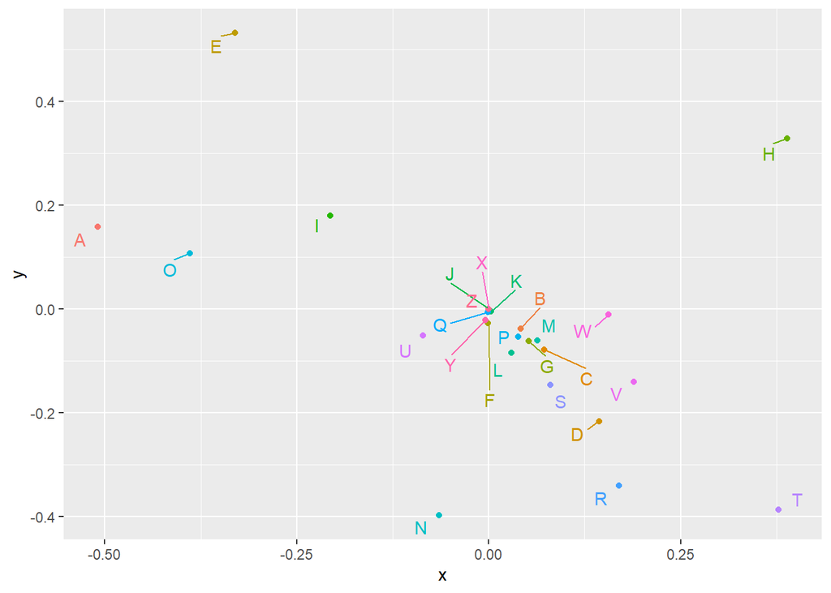

```r
data = data.frame(x = G.out$u[,2],
                  y = G.out$v[,2],
                  label = letters)
ggplot(data, aes(x = x, y = y, label = label, color = as.factor(label))) +
  geom_point() +
  geom_text_repel(max.overlaps = Inf, force_pull =0 , force = 10) +
  theme(legend.position = 'none')
```

### f

Looking at the graph for another text.

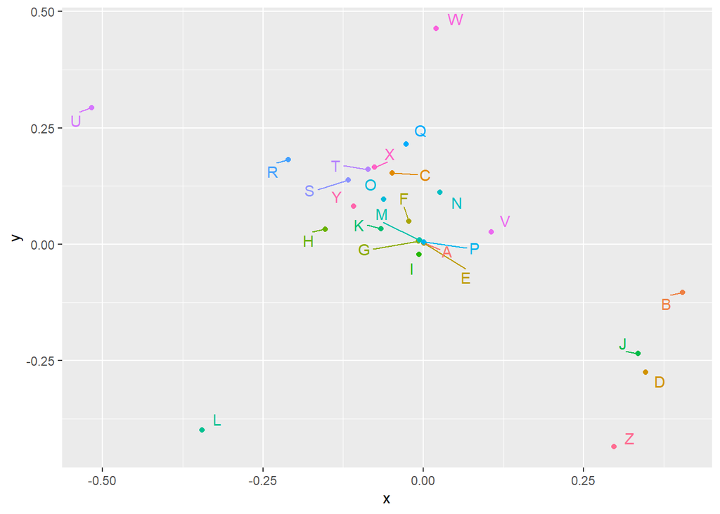

```r
S.out = svd(S)

data = data.frame(x = S.out$u[,2] ,
                  y = S.out$v[,2],
                  label = letters)
ggplot(data, aes(x = x, y = y, label = label, color = as.factor(label))) +
  geom_point() +
  geom_text_repel(max.overlaps = Inf, force_pull =0 , force = 10) +
  theme(legend.position = 'none')
```

Apply the rotation to flip $x-axis$ and $y-axis$ to get the following graph:

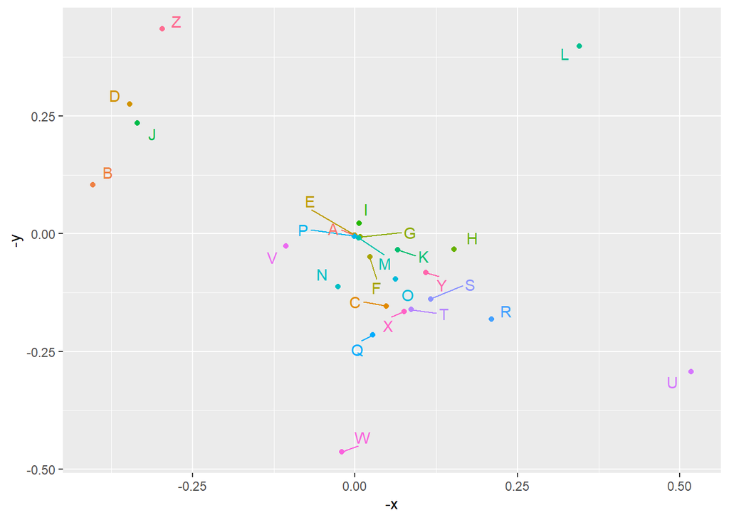

```r
ggplot(data, aes(x = -x, y = -y, label = label, color = as.factor(label))) +
  geom_point() +
  geom_text_repel(max.overlaps = Inf, force_pull =0 , force = 10) +
  theme(legend.position = 'none')
```

What noticeable here is the cluster of four letters $Z,D, J, B$ that is similar to the cluster of $E,A,O,I$. So we can make a guess that these four letters ($Z,D, J, B$) are the four vowels $E,A,O,I$, but not necessarily in that order. The $V$ might be $U$.

To confirm the guess, we can try to look at the encrypted letter to see if we can get any meaningful work from the our mapping.

### Extra Credit

```r
text = "d lbyz b crzbt ulbu ti njvr xduuxz sldxcrzw hdxx jwz cbi xdyz dw b wbudjw hlzrz ulzi hdxx wju kz mvcozc ki ulz sjxjr jn ulzdr qadw kvu ki ulz sjwuzwu jn ulzdr slbrbsuzr"
```

**One-letter words**

`d` is a one-letter word so this must be either $A$ or $I$.

`b` is another one-letter word in the text and appears more than $D$ so $B$ is more likely to be $A$ than $I$.

`z` is in the closest position to $E$.

- `d` $\rightarrow$ `I`
- `b` $\rightarrow$ `A`
- `z` $\rightarrow$ `E`
- `j` $\rightarrow$ `O`
- `l` $\rightarrow$ `H`
- `u` $\rightarrow$ `T`
- `r` $\rightarrow$ `R`

**Two-letter words**: $am,an,as,at,be,by,do,go,he,if,in,is,it,me,my,no,of,on,or,so,to,up,us,we$.

```r
idx = function(c){match(toupper(c), letters)}
two_letter_bank=strsplit("am,an,as,at,be,by,do,go,he,if,in,is,it,me,my,no,of,on,or,so,to,up,us,we", split = ",")

two_letter = spMatrix(ncol = 26, nrow = 26, )
for(word in two_letter_bank[[1]]){
  char = strsplit(word, split='')
    two_letter[idx(char[[1]][1]),idx(char[[1]][2])] = 1
}
colnames(two_letter) <- letters
rownames(two_letter) <- letters
printSpMatrix(two_letter, col.names = 1)
```

```
##   A B C D E F G H I J K L M N O P Q R S T U V W X Y Z
## A . . . . . . . . . . . . 1 1 . . . . 1 1 . . . . . .
## B . . . . 1 . . . . . . . . . . . . . . . . . . . 1 .
## C . . . . . . . . . . . . . . . . . . . . . . . . . .
## D . . . . . . . . . . . . . . 1 . . . . . . . . . . .
## E . . . . . . . . . . . . . . . . . . . . . . . . . .
## F . . . . . . . . . . . . . . . . . . . . . . . . . .
## G . . . . . . . . . . . . . . 1 . . . . . . . . . . .
## H . . . . 1 . . . . . . . . . . . . . . . . . . . . .
## I . . . . . 1 . . . . . . . 1 . . . . 1 1 . . . . . .
## J . . . . . . . . . . . . . . . . . . . . . . . . . .
## K . . . . . . . . . . . . . . . . . . . . . . . . . .
## L . . . . . . . . . . . . . . . . . . . . . . . . . .
## M . . . . 1 . . . . . . . . . . . . . . . . . . . 1 .
## N . . . . . . . . . . . . . . 1 . . . . . . . . . . .
## O . . . . . 1 . . . . . . . 1 . . . 1 . . . . . . . .
## P . . . . . . . . . . . . . . . . . . . . . . . . . .
## Q . . . . . . . . . . . . . . . . . . . . . . . . . .
## R . . . . . . . . . . . . . . . . . . . . . . . . . .
## S . . . . . . . . . . . . . . 1 . . . . . . . . . . .
## T . . . . . . . . . . . . . . 1 . . . . . . . . . . .
## U . . . . . . . . . . . . . . . 1 . . 1 . . . . . . .
## V . . . . . . . . . . . . . . . . . . . . . . . . . .
## W . . . . 1 . . . . . . . . . . . . . . . . . . . . .
## X . . . . . . . . . . . . . . . . . . . . . . . . . .
## Y . . . . . . . . . . . . . . . . . . . . . . . . . .
## Z . . . . . . . . . . . . . . . . . . . . . . . . . .
```

From the text we have $ti,ki,kz ,jn, dw$ We know that $z = e$, so $kz \in \{BE, HE, ME, WE\}$. $k$ have to be a letter that need to satisfy $kz, ki$, so we need to check each row of $B,H, M, W$. They must have at least 2 combination. This narrow down $kz \in \{BE, ME\}$ and $ki \in \{BY, MY\}$. This mean $i = Y$

`ulzi` = $THEY$ `ulbu` = $THAT$ `ulzdr` = $THEIR$

Looking at `dw` and `wju`: `Iw` `wOT`. Check the the row of $I$ in matrix, we can guess that $w = N$.

`dw` = $IN$ `wju` = $NOT$

Looking at the phrase `kvu kY THE sjwuzwu`, we can confirm that $k = B$ and $t = M$.

`ki` = $BY$ `kz` = $BE$ `ti` = $MY$

We can find `jn` but filter out the letter that already mapped from the matrix (M,B,Y,E,I,N).

```r
remain_letter = setdiff(letters, c('M','B','Y','E','I','N'))
remain_idex = match(remain_letter, letters)

remain_matrix = two_letter[remain_idex, remain_idex]
colnames(remain_matrix) <- remain_letter
rownames(remain_matrix) <- remain_letter
printSpMatrix(remain_matrix, col.names = 1)
```

```
##   A C D F G H J K L O P Q R S T U V W X Z
## A . . . . . . . . . . . . . 1 1 . . . . .
## C . . . . . . . . . . . . . . . . . . . .
## D . . . . . . . . . 1 . . . . . . . . . .
## F . . . . . . . . . . . . . . . . . . . .
## G . . . . . . . . . 1 . . . . . . . . . .
## H . . . . . . . . . . . . . . . . . . . .
## J . . . . . . . . . . . . . . . . . . . .
## K . . . . . . . . . . . . . . . . . . . .
## L . . . . . . . . . . . . . . . . . . . .
## O . . . 1 . . . . . . . . 1 . . . . . . .
## P . . . . . . . . . . . . . . . . . . . .
## Q . . . . . . . . . . . . . . . . . . . .
## R . . . . . . . . . . . . . . . . . . . .
## S . . . . . . . . . 1 . . . . . . . . . .
## T . . . . . . . . . 1 . . . . . . . . . .
## U . . . . . . . . . . 1 . . 1 . . . . . .
## V . . . . . . . . . . . . . . . . . . . .
## W . . . . . . . . . . . . . . . . . . . .
## X . . . . . . . . . . . . . . . . . . . .
## Z . . . . . . . . . . . . . . . . . . . .
```

Since we know that `j` = $O$, then $n \in \{F, R\}$. Looking at `njvr` = `nOvR`, we can guess that $n = F$ and $v = U$

`njvr` = $FOUR$ `jn` = $OF$ `kvu` = $BUT$

Looking at `cREAM`, `cAY`, so $c = D$

**Use Context**  
Replace known characters in the text and guess based on the meaning. Repeat until all the words are decrypted. The Final mapping:

- `d` $\rightarrow$ `I`
- `b` $\rightarrow$ `A`
- `z` $\rightarrow$ `E`
- `j` $\rightarrow$ `O`
- `l` $\rightarrow$ `H`
- `u` $\rightarrow$ `T`
- `r` $\rightarrow$ `R`
- `i` $\rightarrow$ `Y`
- `w` $\rightarrow$ `N`
- `t` $\rightarrow$ `M`
- `k` $\rightarrow$ `B`
- `n` $\rightarrow$ `F`
- `v` $\rightarrow$ `U`
- `c` $\rightarrow$ `D`
- `y` $\rightarrow$ `V`
- `s` $\rightarrow$ `C`
- `x` $\rightarrow$ `L`
- `h` $\rightarrow$ `W`
- `m` $\rightarrow$ `J`
- `o` $\rightarrow$ `G`
- `q` $\rightarrow$ `S`
- `a` $\rightarrow$ `K`